# Examining the role of transcription and post-transcriptional modifications on mediating intragenomic conflict in honey bees: QC and differential gene expression

Lindsay Clark, HPCBio, Roy J. Carver Biotechnology Center, University of Illinois, Urbana-Champaign

Modified for publication by Sean Bresnahan, Huck Institutes of the Life Sciences, Pennsylvania State University

2022-12-22

## Results files

- `results/differential_gene_expression_results_2022-06-30.xlsx` has differential gene expresion results.
- `gene_counts_2022-06-27.xlsx` contains raw read counts summarized to gene.
- `filtered_logCPM_2022-06-30.xlsx` contains normalized and filtered logCPM (log2(counts-per-million)) values.
- `flair/2022-06-14` contains output directly from the flair software for calling isoforms from long read data.
  - Files beginning with “All_samples_collapse.isoforms” document the isoforms called by flair in terms of sequence and genomic location.
  - Files beginning with “counts_matrix” contain the results of transcript quantification by flair.

Additionally, all scripts and code for the full analysis are available at https://github.com/sbresnahan/allele-specific-transcription-and-m6A.

## Study design

This study seeks to use transcriptome data to understand behavioral differences between non-aggressive and aggressive honey bees. Two crosses were made. Cross A had AHB as the female parent (SRR14654188) and EHB as the male parent (SRR14654189). Cross B had EHB as the female parent (SRR14654186) and AHB as the male parent (SRR14654187). Three or more aggressive bees and three or more non-aggressive bees (labeled C and T) were collected from each cross. Twelve head and abdomen samples, spanning multiple batches over the course of a year, were ultimately analyzed, with three samples per experimental group. RNA samples were sequenced with Oxford Nanopore Technology direct RNA sequencing on a FLO-MIN106 flowcell.

In this report, I analyze differential gene expression.

## Sample processing

FAST5 files from all samples were processed with Guppy 5.0.16 using the `rna_r9.4.1_70bps_hac.cfg` configuration (Oxford Nanopore Technologies) for base calling on a GPU. FASTQ files labeled “pass” were concatenated together to generate one FASTQ per sample. [Minimap 2.21](https://github.com/lh3/minimap2)[^1] was used for alignment to the [*Apis mellifera* HAv3.1 reference genome](https://www.ncbi.nlm.nih.gov/genome/48?genome_assembly_id=403979) (plus common viral genomes) in splice-aware mode with a kmer length of 14, using the published gene annotation to guide alignment. [SAMtools 1.12](https://github.com/samtools/samtools)[^2] was used to sort and index the resulting BAM files. [Flair 1.5](https://github.com/BrooksLabUCSC/flair)[^3] was then used to convert BAM files to BED format and correct intron-exon junctions based on the published annotation, then call isoforms across all samples. These isoforms included published transcripts and genes as well as novel transcripts and genes.

VCF files from Sean Bresnahan for the four parent bees (NCBI samples SRR14654186, SRR14654187, SRR14654188, and SRR14654189) were used together with the transcriptome output by flair to generate parent-specific transcriptomes using a custom R script. For each cross, the two parental transcriptomes were combined, with identical transcripts being labeled “Both” and transcripts differing between parents being labeled with the parent ID. Flair was then used separately for each cross to quantify transcript abundance across samples.

For differential gene expression analysis, counts were summed within genes regardless of parent ID or transcript ID, resulting in counts for 19,920 genes. Samples from both crosses were combined into one gene count matrix.

Counts at the transcript level were not used in this analysis aside from quality control (*i.e.* tallying annotated vs. novel isoforms) but were used in a separate analysis of differential isoform expression.

## Quality control

Libraries varied considerably in overall size (Fig. 1) but were similar in quality (Fig. 2). Two samples had low levels of viral contamination (Fig. 2). Most reads mapping to the nuclear genome mapped to annotated transcripts (Fig. 2). Number of genes detected was linearly correlated with library size, indicating that saturation of gene detection was not reached (Fig. 3). The A-C group, which consisted entirely of new samples from December 2021, had the smallest library size and lowest number of genes detected (Figs. 1 and 3).

Samples from cross A had far fewer reads mapping to the mitochondrial genome than samples from cross B did (Figs. 1 and 2). I determined that one of the novel nuclear genes called by Flair, NC_037641.1:1186000, was was highly similar in sequence to a region of the mitochondrial genome spanning the l-rRNA and ND1 genes. For the EHB parents, the sequence of this nuclear region was distinct from the mitochondrial region, and mitochondrial reads mapped correctly. However, for AHB parents, SNP calls in the VCF were applied very similarly to both the nuclear and mitochondrial regions, causing mitochondrial reads to be mapped incorrectly to the nuclear region. I do not anticipate that this mismapping will cause issues downstream, particularly after filtering mitochondrial reads (see below).

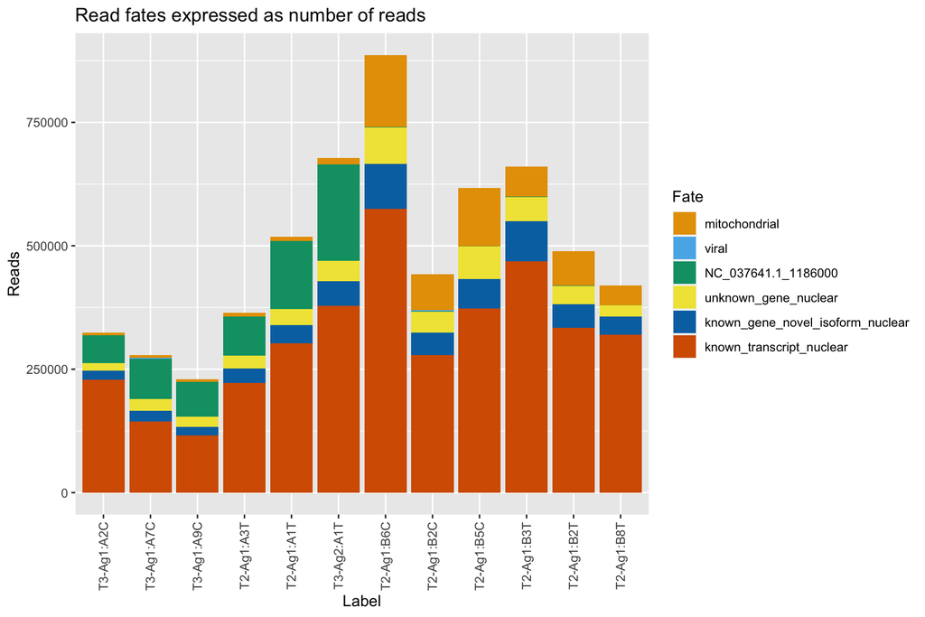

Fig. 1. Library sizes expressed as number of aligned reads.

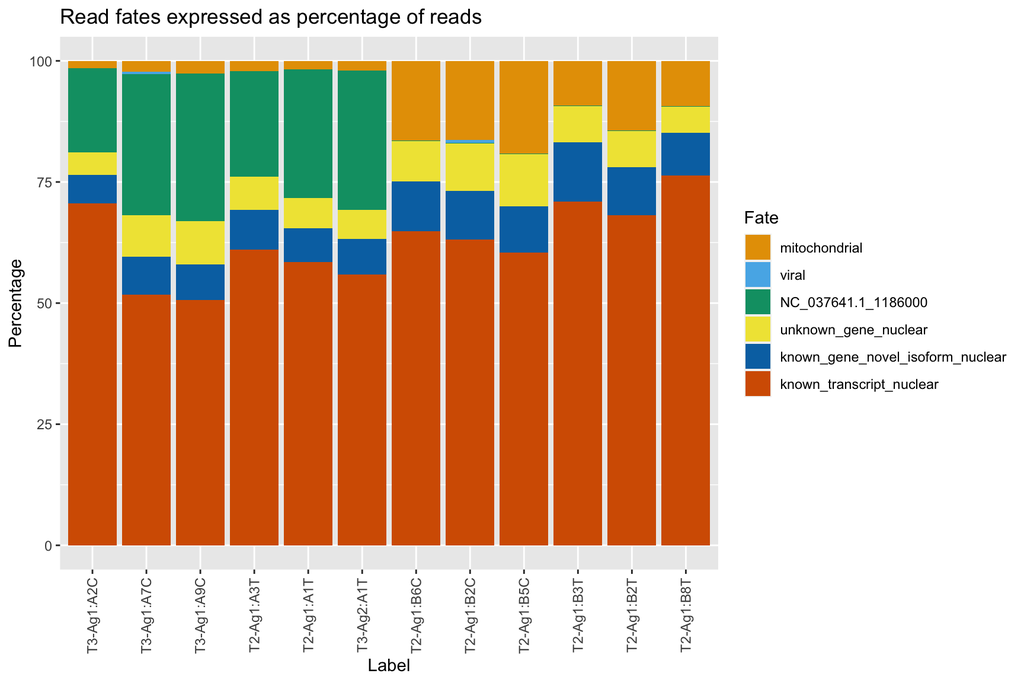

Fig. 2. Percentages of reads aligned to categories of transcripts.

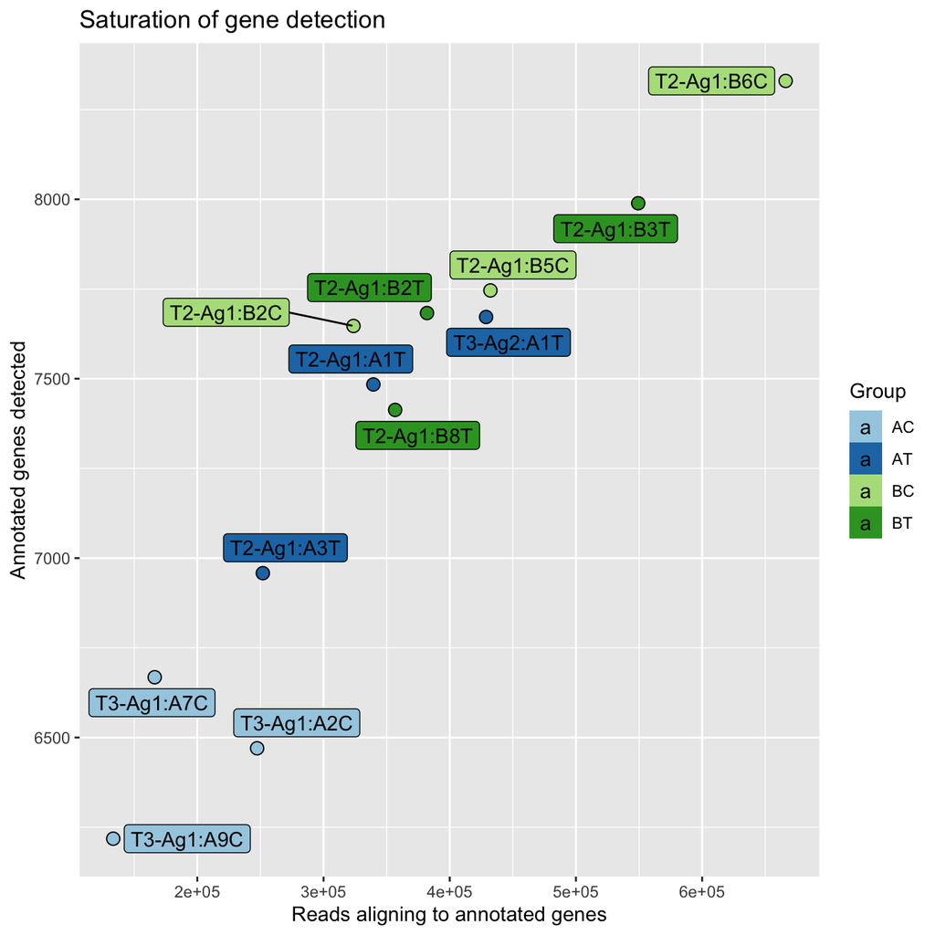

Fig. 3. Number of genes detected vs. number of reads aligning to genes. Only genes from the published annotation are considered.

## Mitochondrial reads

The vast majority of reads mapping to mitochondrial transcripts mapped correctly to the mother in both crosses (Figs. 4 and 5). Because of the mismapping of mitochondrial reads to the nuclear genome (NC_037641.1:1186000) in cross A, I excluded from downstream analysis all mitochondrial reads including those mapping to NC_037641.1:1186000. I found that this filtering reduced variance in TMM normalization factors (data not shown).

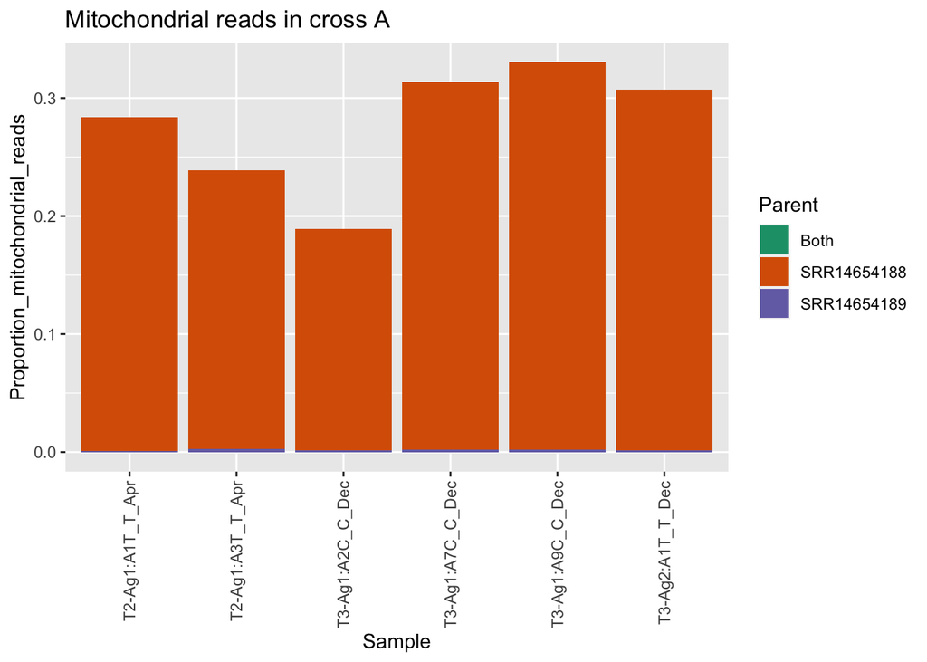

Fig. 4. Proportion of read assigned to the materinal mitochondrion (SRR14654188), paternal mitochondrion (SRR14654189) or mitochondrion of unknown parent (Both) in cross A. Reads assigned to gene NC_037641.1:1186000 are counted as mitochondrial.

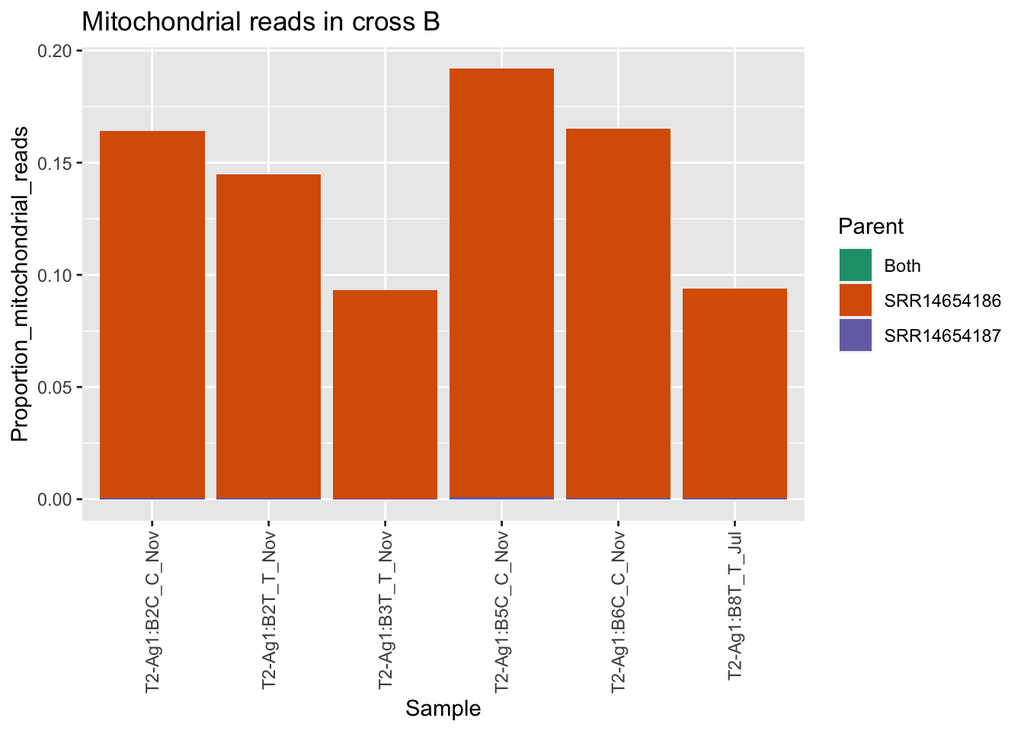

Fig. 5. Proportion of read assigned to the materinal mitochondrion (SRR14654186), paternal mitochondrion (SRR14654187) or mitochondrion of unknown parent (Both) in cross B. Reads assigned to gene NC_037641.1:1186000 are counted as mitochondrial.

## Normalization and filtering

When comparing expression levels, the numbers of reads per gene need to be normalized not only because of the differences in total number of reads, but because there could be differences in RNA composition such that the total number of reads would not be expected to be the same. The TMM (trimmed mean of M values) normalization[^4] in the [edgeR](https://bioconductor.org/packages/release/bioc/html/edgeR.html) package[^5] uses the assumption of *most genes do not change* to calculate a normalization factor for each sample to adjust for such biases in RNA composition. In this dataset, TMM normalization factors fluctuated between 0.79 and 1.21. TMM normalization factors are multiplied by the library size in order to generate the effective library size, where smaller TMM normalization factors indicate more overrepresented genes in the sample. Normalization factors varied among samples but were not particularly associated with experimental group (Fig. 6).

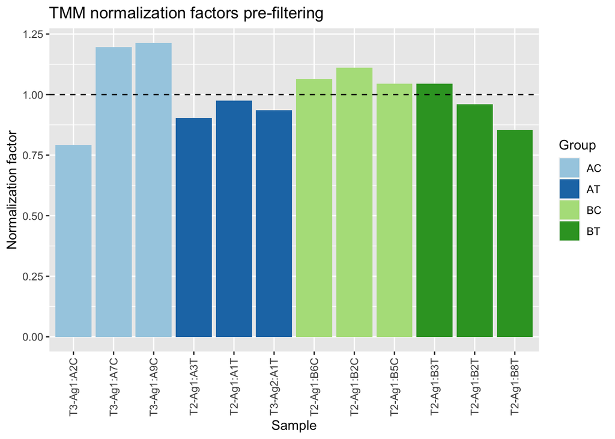

Fig. 6. TMM normalization factors pre-filtering.

While the `flair collapse` output a total of 19,902 genes (after filtering mitochondrial genes), many of these might not have detectable expression in these samples. Therefore, we set the detection threshold at 8 cpm (counts per million) in at least 3 samples, which resulted in 5,440 genes being filtered out, leaving 14,462 genes to be analyzed for differential expression, containing 99.42% of the reads. Of these genes, 8058 were from the published annotation, representing 90.30% of reads prior to filtering. This threshold resulted in a fairly even number of genes being detected across samples, considering the variability in library size (Fig. 7). In a typical Illumina RNA-seq experiment, we might use 1 cpm as the filtering threshold. Given the lower read depth of this experiment due to the use of Oxford Nanopore sequencing, a higher threshold was needed to differentiate between genes that could be detected in few samples vs. genes that could be detected in most samples. I arrived at a threshold of 8 by examining the detection rates at a variety of thresholds ranging from 4 to 12 (results not shown).

After filtering, TMM normalization was performed again and normalized log2-based count per million values (logCPM) were calculated using edgeR’s[^6] `cpm()` function with `prior.count = 2` to help stabilize fold-changes of extremely low expression genes. TMM normalization factors after filtering are shown in Fig. 8, and compared to pre-filtering values in Fig. 9.

The overall distribution of logCPM values differed by batch (Fig. 10). The peak on the left of Fig. 10 represents undetected genes, and thus is higher in batches later than November 2020 because those library sizes were smaller.

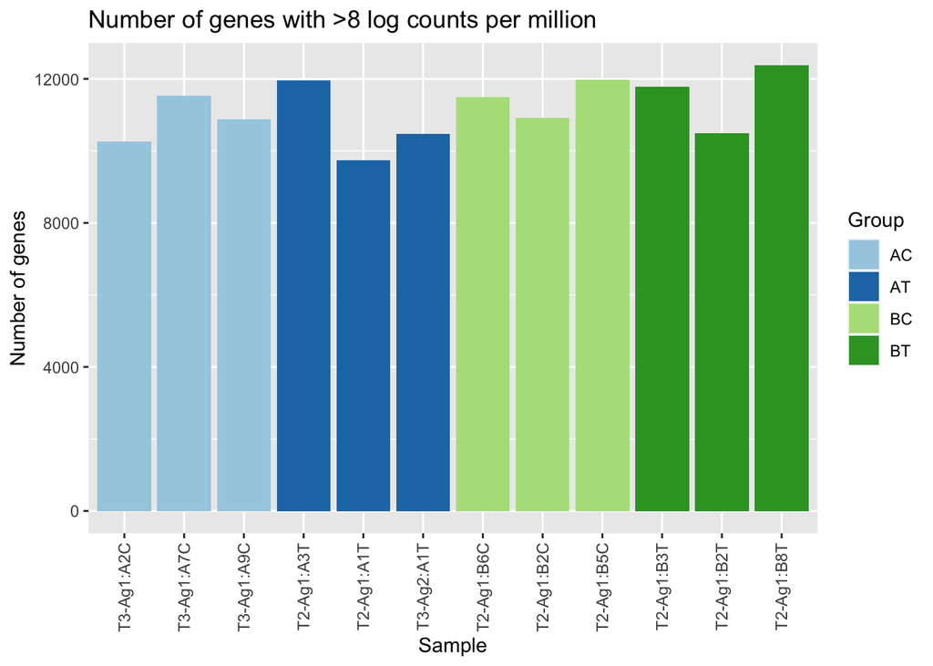

Fig. 7. Number of detected genes passing the filtering threshold in each sample.

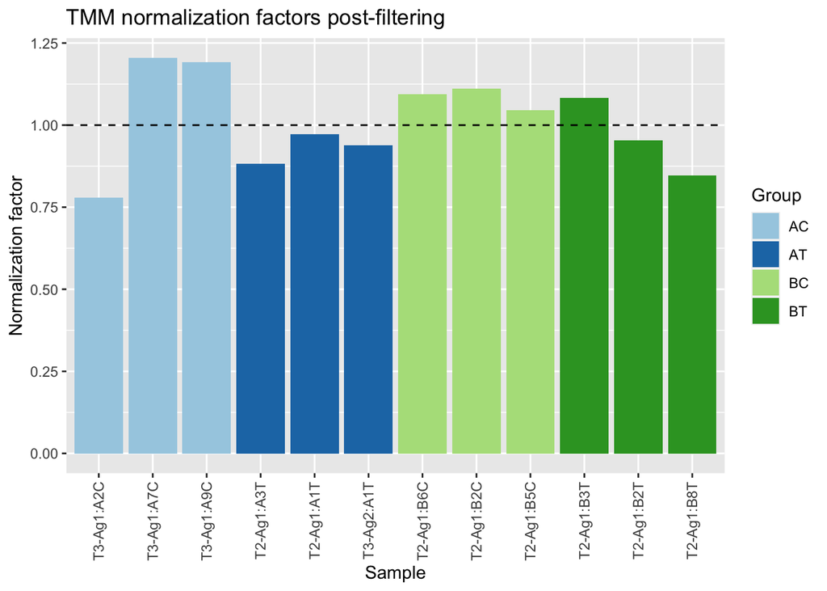

Fig. 8. TMM normalization factors post-filtering.

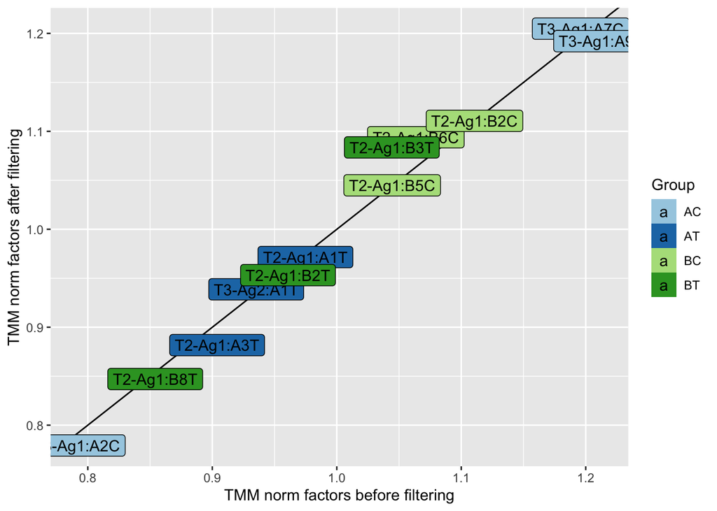

Fig. 9. Comparison of TMM normalization factors before and after filtering.

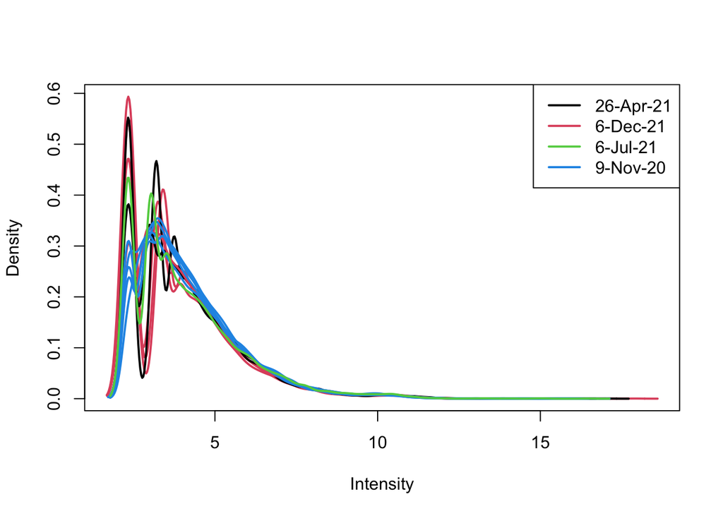

Fig. 10. Distribution of logCPM values after filtering.

## Sample clustering

Multidimensional scaling in the [limma](https://bioconductor.org/packages/release/bioc/html/limma.html)[^7] package was used to assess the largest effects on gene composition among samples. The normalized logCPM values of the top most 5,000 variable genes between each pair of samples were chosen to construct the multidimensional scaling plot. The first axis separated the two crosses, while the second axis separated sample T3-Ag1:A2C from the rest and to a lesser extent separated C and T samples (Fig. 11).

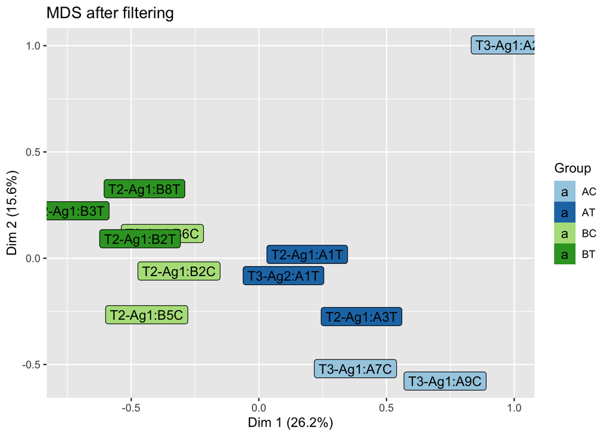

Fig. 11. Multidimensional scaling of samples after filtering, using the top 5000 variable genes between each pair of samples.

## Differential gene expression

Differential gene expression (DE) analysis was performed using the limma-trend method[^8]. Multiple testing correction was done using the False Discovery Rate method[^9]. The model run was:

$Y = Group$

where $Group$ refers to the AC, AT, BC, and BT groups. The following contrasts were then assessed:

- **BT - BC**: Differences between T and C bees from the B cross
- **AT - AC**: Differences between T and C bees from the A cross
- **BC - AC**: Differences between B and A crosses, with C as the baseline
- **(BT + AT) - (BC + AC)**: Differences between T and C bees across both crosses
- **(BT + BC) - (AT + AC)**: Differences between crosses, looking at both C and T
- **(BT - BC) - (AT - AC)**: Interaction effect; differential effect of cross on differences between T and C bees

Numbers of significantly up- and down-regulated genes are shown in Table 1.

Table 1. Number of gene significant for differential expression at FDR < 0.05.

|  | BT - BC | AT - AC | BC - AC | (BT + AT) - (BC + AC) | (BT + BC) - (AT + AC) | (BT - BC) - (AT - AC) |
| --- | --- | --- | --- | --- | --- | --- |
| Down | 0 | 0 | 133 | 0 | 306 | 0 |
| NotSig | 14461 | 14461 | 13922 | 14462 | 13465 | 14462 |
| Up | 1 | 1 | 407 | 0 | 691 | 0 |

## Heatmaps for differential gene expression

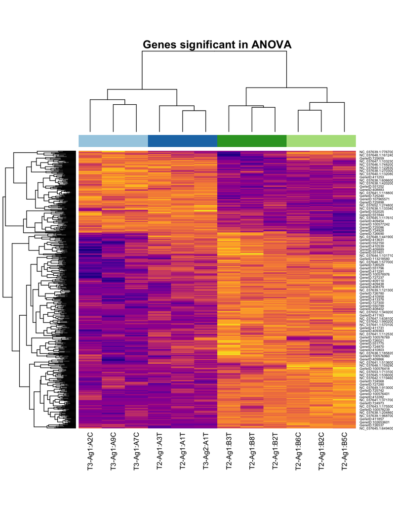

Fig. 12. Heatmap of 582 genes with FDR < 0.05 in one-way anova for effect of experimental group. Unadjusted expression values are shown.

## References

[^1]: Li, H. (2018). Minimap2: pairwise alignment for nucleotide sequences. Bioinformatics, 34:3094-3100. doi:10.1093/bioinformatics/bty191
[^2]: Petr Danecek, James K Bonfield, Jennifer Liddle, John Marshall, Valeriu Ohan, Martin O Pollard, Andrew Whitwham, Thomas Keane, Shane A McCarthy, Robert M Davies, Heng Li (2021). Twelve years of SAMtools and BCFtools. GigaScience, Volume 10, Issue 2, giab008, https://doi.org/10.1093/gigascience/giab008
[^3]: Tang, A.D., Soulette, C.M., van Baren, M.J. et al. Full-length transcript characterization of SF3B1 mutation in chronic lymphocytic leukemia reveals downregulation of retained introns. Nat Commun 11, 1438 (2020). https://doi.org/10.1038/s41467-020-15171-6
[^4]: Robinson MD, Oshlack A (2010). A scaling normalization method for differential expression analysis of RNA-seq data. Genome Biology 11, R25.
[^5]: Robinson MD, McCarthy DJ, Smyth GK (2010). “edgeR: a Bioconductor package for differential expression analysis of digital gene expression data.” Bioinformatics, 26(1), 139-140.
[^6]: McCarthy DJ, Chen Y, Smyth GK (2012). “Differential expression analysis of multifactor RNA-Seq experiments with respect to biological variation.” Nucleic Acids Research, 40(10), 4288-4297.
[^7]: Ritchie, M.E., Phipson, B., Wu, D., Hu, Y., Law, C.W., Shi, W., and Smyth, G.K. (2015). limma powers differential expression analyses for RNA-sequencing and microarray studies. Nucleic Acids Research 43(7), e47.
[^8]: Chen Y, Lun ATL and Smyth GK. From reads to genes to pathways: differential expression analysis of RNA-Seq experiments using Rsubread and the edgeR quasi-likelihood pipeline [version 2; referees: 5 approved]. F1000Research 2016, 5:1438 (doi: 10.12688/f1000research.8987.2)
[^9]: Benjamini, Y., & Hochberg, Y. (1995). Controlling the false discovery rate: a practical and powerful approach to multiple testing. Journal of the Royal statistical society: series B (Methodological), 57(1), 289-300.